# Uso de APIs con R

Joselina Davyt

# Acceso a los datos con R

## Maneras de acceder a los datos

- Datos que directamente importas hacia R (Excel, txt, csv, shape, json, etc.)
- Datos de un repositorio propio de base datos (ej.: SQL)
- Datos que se bajan directamente de una URL (o usando la función download.file())
- Los datos que descarga mediante una API que realiza una solicitud a un repositorio de datos y devuelve los datos solicitados

## Dos principales formatos

- Archivo tabular de lectura humana (tienen una estructura plana en lugar de una jerárquica)
- Archivos estructurados legibles por máquina

# ¿Qué es una API?

API es el acrónimo de Application Programming Interface, que es un intermediario de software que permite que dos aplicaciones se comuniquen entre sí.

[figure not shown]

## Un lenguaje común de comunicación

Las entradas y salidas variarán entre las API, pero el proceso es el mismo: se envía una “solicitud” que sigue ciertas reglas programáticas y se devuelve una “respuesta” que contiene contenido en un formato esperado.

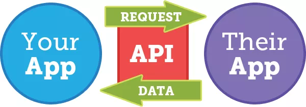

## Endpoints

El primer paso es localizar el endpoint deseado de la API. La mayoría de las APIs tienen documentación online que explican que tipo de información puede ser requerida. Ejemplo: API Banco Mundial:

[figure not shown]

## Request

## Response

## Mejores prácticas

Las claves principales de cualquier API son la estructura de las solicitudes y la estructura de las respuestas. Una solicitud HTTP consiste en las siguientes partes:

- verbos HTTP (GET, POST, DELETE, etc.)
- La URL base de la API
- El path o endpoint de interés
- Si la URL tiene argumentos query (e.g., ?foo=bar)
- Optional headers
- Conocer el estado de la respuesta (ver: https://cran.r-project.org/web/packages/httr/vignettes/api-packages.html)

## Errores

[figure not shown]

# Extraer datos de APIs con R: las básicas

### Los principales paquetes

- RCurl, httr
- JSON: jsonlite, rjson
- XML: XML, R4X

### Herramientas específicas de datos de APIs

- Google: RGA, googleVis, translate, others
- twitteR (Twitter)
- Rook / Rfacebook (Facebook)
- tumblR (Tumblr)
- Otros: dvn (Dataverse), WDI (World Bank), etc. (ver: http://cran.r-project.org/web/views/WebTechnologies.html)

# Ejemplo datos de clima con: RCurl y rjson

## Objetos a crear necesarios para bajar datos de clima. La API requiere autentificación (clave)

```r
library(RCurl)
library(rjson)
key='5a9bd6cf09ce38ec2755e059ab9944af'
pais='BR'
ciudad = 'Curitiba'
url_base="http://api.openweathermap.org/data/2.5/weather?q="
```

## Obtener los datos del clima para Brasil

```r
URL = paste0(url_base,ciudad,',',pais,'&APPID=', key)
d= fromJSON(getURL(URL))
print(d)
```

```
## $coord
## $coord$lon
## [1] -49.27
##
## $coord$lat
## [1] -25.43
##
##
## $weather
## $weather[[1]]
## $weather[[1]]$id
## [1] 800
##
## $weather[[1]]$main
## [1] "Clear"
##
## $weather[[1]]$description
## [1] "clear sky"
##
## $weather[[1]]$icon
## [1] "01d"
##
##
##
## $base
## [1] "stations"
##
## $main
## $main$temp
## [1] 302.15
##
## $main$pressure
## [1] 1018
##
## $main$humidity
## [1] 37
##
## $main$temp_min
## [1] 302.15
##
```

[output cut: 36 more lines]

```
## $sys$sunrise
## [1] 1544602806
##
## $sys$sunset
## [1] 1544652147
##
##
## $id
## [1] 6322752
##
## $name
## [1] "Curitiba"
##
## $cod
## [1] 200
```

## Podemos hacerlo como una función y aplicar la función a varias ciudades

```r
myfun <- function(ciudad){
  url = "http://api.openweathermap.org/data/2.5/weather?q="
  pais = 'BR'
  key = '5a9bd6cf09ce38ec2755e059ab9944af'
  URL = paste0(url, ciudad, ',', pais,'&APPID=',key)
  d=getURL(URL)
  d=(fromJSON(d))
}
ciudades=c('Curitiba', 'Brasilia')
b <- lapply(ciudades, myfun)
print(b)
```

```
## [[1]]
## [[1]]$coord
## [[1]]$coord$lon
## [1] -49.27
##
## [[1]]$coord$lat
## [1] -25.43
##
##
## [[1]]$weather
## [[1]]$weather[[1]]
## [[1]]$weather[[1]]$id
## [1] 800
##
## [[1]]$weather[[1]]$main
## [1] "Clear"
##
## [[1]]$weather[[1]]$description
## [1] "clear sky"
##
## [[1]]$weather[[1]]$icon
## [1] "01d"
##
##
##
## [[1]]$base
## [1] "stations"
##
## [[1]]$main
## [[1]]$main$temp
## [1] 302.15
##
## [[1]]$main$pressure
## [1] 1018
##
## [[1]]$main$humidity
## [1] 37
##
## [[1]]$main$temp_min
## [1] 302.15
```

[output cut: 131 more lines]

```
## [[2]]$sys$sunrise
## [1] 1544601698
##
## [[2]]$sys$sunset
## [1] 1544647625
##
##
## [[2]]$id
## [1] 3459342
##
## [[2]]$name
## [1] "Brasilia"
##
## [[2]]$cod
## [1] 200
```

```r
df <- plyr::ldply (b, data.frame)
```

# Ejemplo datos de Banco Mundial con: httr

API keys or other special authentication methods are no longer necessary to access the API. Endponit: countries API query For XML format: http://api.worldbank.org/v2/countries/br For JSON format: http://api.worldbank.org/v2/countries/br?format=json

```r
library(httr)
url_base_wb <- "http://api.worldbank.org/v2"
pais <- "br"
query_pais <- sprintf("countries/%s?format=json", pais)
url_pais <- paste0(url_base_wb, "/", query_pais)
tmp_pais <- GET(url_pais)
datos_pais <- content(tmp_pais)
print(datos_pais)
```

```
## [[1]]
## [[1]]$page
## [1] 1
##
## [[1]]$pages
## [1] 1
##
## [[1]]$per_page
## [1] "50"
##
## [[1]]$total
## [1] 1
##
##
## [[2]]
## [[2]][[1]]
## [[2]][[1]]$id
## [1] "BRA"
##
## [[2]][[1]]$iso2Code
## [1] "BR"
##
## [[2]][[1]]$name
## [1] "Brazil"
##
## [[2]][[1]]$region
## [[2]][[1]]$region$id
## [1] "LCN"
##
## [[2]][[1]]$region$iso2code
## [1] "ZJ"
##
## [[2]][[1]]$region$value
## [1] "Latin America & Caribbean "
##
##
## [[2]][[1]]$adminregion
## [[2]][[1]]$adminregion$id
## [1] "LAC"
##
```

[output cut: 22 more lines]

```
## [[2]][[1]]$lendingType$iso2code
## [1] "XF"
##
## [[2]][[1]]$lendingType$value
## [1] "IBRD"
##
##
## [[2]][[1]]$capitalCity
## [1] "Brasilia"
##
## [[2]][[1]]$longitude
## [1] "-47.9292"
##
## [[2]][[1]]$latitude
## [1] "-15.7801"
```